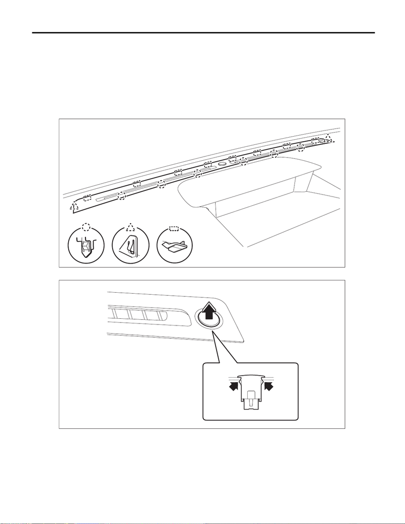

LI-21

Light Control Sensor

LIGHTING SYSTEM

13.Light Control Sensor

A: REMOVAL

1) Disconnect the ground cable from battery. <Ref. to NT-5, BATTERY, NOTE, Note.>

NOTE:

For models other than STI model, disconnect the ground terminal from battery sensor.

2) Remove the panel COMPL - instrument UPR.

(1) Release the claws.

(2) Disconnect the connectors and remove the panel COMPL - instrument UPR.

3) Release the claws, and then remove the sensor - automatic light.

B: INSTALLATION

1) Install the sensor - automatic light.

2) Install the panel COMPL - instrument UPR.

3) Connect the battery ground terminal. <Ref. to NT-5, BATTERY, NOTE, Note.>

NOTE:

For models other than STI model, connect the ground terminal to battery sensor.

LI-01185

LI-01713

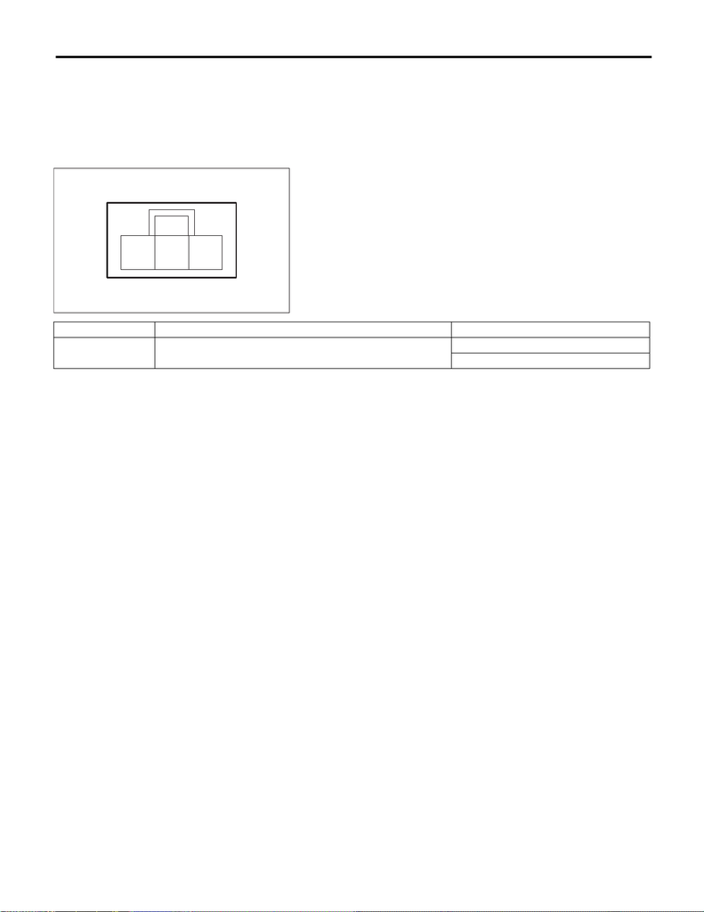

LI-22

Light Control Sensor

LIGHTING SYSTEM

C: INSPECTION

1) Connect the connector and then turn the ignition to ON.

2) Set the lighting switch to AUTO position.

3) Measure the voltage between connector terminals.

Preparation tool:

Circuit tester

4) Replace the sensor - automatic light if the inspection result is not within the standard value.

LI-01714

3 1

2

Terminal No. Inspection conditions Standard

2 (+) — 1 (–)

Measure the voltage when the area around the sensor - auto-

matic light, which was dark, becomes bright.

Dark condition: Approx. 0.6 V or less

Bright condition: Approx. 3.0 V or more